# Chapter 07

리스트는 파이썬 자료구조의 꽃으로, 아주 유연한 구조이다. 리스트는 아주 많은 데이터를 집어 넣어놓은 데이터들의 집합이라고 할 수 있다. 튜플은 리스트와 상당히 비슷하지만 읽기만 할 수 있다. 처음 만든 후 추가로 넣은 수 없고 꺼낼 수만 있다. 딕셔너리는 말 그대로 사전과 같은 구성으로 활용된다.

- 리스트의 개념을 이해하고 활용한다.
- 2차원 리스트 생성법을 익힌다
- 튜플을 이해하고 리스트와 차이점을 파악한다
- 딕셔너리의 개념과 활용법을 익힌다

# 1. 리스트의 기초

- 리스트는 여러 개의 데이터를 한번에 담을 수 있는 자료구조
- 단독으로 사용되기보다는 for문 등과 함께 사용되는 경우가 많다.
- 수준 높은 코드에 필수적으로 사용된다.

## 1) 리스트의 개념

- 변수의 개념을 그릇, 박스 등에 다양한 물체에 비유해 왔다.
- 리스트의 경우 종이상자로 비유하면 조금 더 이해하기 쉽다.

#### 여러 개 변수의 사용

- num1 ~ num4까지 4개의 변수 선언하여 준비한다.

[figure not shown]

### 먼저, 지금까지 배운 지식으로 4개 변수의 합을 구현해보자!

- 4개의 변수를 선언한 후(혹은 입력받은 후) 변수를 더해 출력한다

```
숫자 : 1
숫자 : 2
숫자 : 3
숫자 : 4
합계 ==>  10
```

**접기/펼치기**

num1, num2, num3, num4 = 0, 0, 0, 0

num1 = int(input("숫자 : "))  
num2 = int(input("숫자 : "))  
num3 = int(input("숫자 : "))  
num4 = int(input("숫자 : "))

hap = num1 + num2 + num3 + num4

print("합계 ==> " ,hap)

### 변수 4개의 선언은 매우 간단하다

- 하지만 4개가 아닌, 100개, 1000개의 변수를 선언하여 더해주어야 한다면?
- 매우 귀찮은 일이 될 것.따라서 이런 상황이 바로 리스트가 필요한 이유가 된다.

### 리스트의 생성

- 리스트(List)는 다음 그림과 같이 하나씩 사용하던 변수를 이어붙여서 한줄로 붙여놓은 개념
- 종이상자들을 이어붙이면, 변수 이름(아래에서는 numList라 지정)을 하나 지정하여 사용하면 된다.
- 리스트도 변수이기에, 이름은 마음대로 정하면 된다.
- 각 데이터는 인덱스(번호)를 통해 접근하면 된다.

[figure not shown]

- 리스트를 만드는 형식은 다음과 같이 대괄호 [ ] 안에 값들을 선언하면 된다.
- 4개, 혹은 그 이상의 값을 넣어 정수형 리스트를 생성해보자

```python
list_name = [10,20,30,40]
```

```python
print(list_name)
```

```
[10, 20, 30, 40]
```

### 각 변수를 사용하는 경우 vs 리스트를 사용하는 경우

- 리스트를 사용하지 않는다면 각각의 변수와 값을 선언해주어야 한다.
- 리스트를 사용하게 되면, 한 번의 선언 후 각각의 인덱스(번호)를 사용하여 접근해주면 된다.
- 개수가 4개인 리스트를 생성했다면, 인덱스는 1 ~ 4까지가 아닌, 0 ~ 3으로 이루어져 있음을 기억해야 된다.

[figure not shown]

### 위에서 생성해본 리스트를 사용하여 인덱스 번호로 각 위치의 값 확인하기

```python
list_name = [10,20,30,40]
```

```python
list_name[0]
```

```
10
```

```python
list_name[1]
```

```
20
```

```python
list_name[2]
```

```
30
```

```python
list_name[3]
```

```
40
```

#### list_name[3] 값은 ?

```python
list_name = [1,10,100,1000,10000]
```

```python
list_name[3]
```

```
1000
```

### 리스트는 가변(mutable)한 자료구조로, 쉽게 값을 변경할 수 있다.

- 리스트는 여러 개의 값을 담을 수 있고, 각 요소는 인덱스를 통해 접근할 수 있다.  
  ※ section2에서 조금 더 자세히 배울 것

```python
list_name = [10,20,30,40]
list_name[1] = 1000
print("수정된 list_name :", list_name)
```

```
수정된 list_name : [10, 1000, 30, 40]
```

- 리스트의 인덱스는 0부터 시작하므로, list_name[0]은 list_name 리스트의 첫 번째 요소를 나타낸다.
- "=" 대입 연산자를 사용하여 오른쪽의 값을 왼쪽 변수에 할당하라는 의미를 가진다.
- 즉, list_name[1] = 1000은 list_name 리스트의 두 번째 요소에 1000을 할당(변경)하라는 의미이다.
- 이를 통해 직접 리스트의 요소에 접근하여 값을 변경하는 작업이 가능하다.

## input( )과 리스트를 사용하여 4개 변수의 합을 구현

- numList = [0, 0, 0, 0] 을 통해 먼저 4개의 값을 가진 리스트 만들어준다.(초기화)
- input() 함수를 사용하여 사용자로부터 4개의 숫자를 입력받도록 코드를 작성한다.
- 입력된 숫자는 int() 함수를 이용하여 정수형으로 변환되어 numList리스트에 각각 저장된다.
- 예를 들어, 첫 번째 입력되는 숫자는 numList[0]에 할당되도록 한다.
- 끝으로 numList 리스트에 저장된 숫자들을 + 연산자를 이용하여 모두 더한 결과를 변수 hap에 저장한다.
- print() 함수를 이용하여 결과를 출력한다.

```
숫자 : 100
숫자 : 200
숫자 : 300
숫자 : 400
합계 ==>  1000
```

**접기/펼치기**

numList = [0, 0, 0, 0]

numList[0] = int(input("숫자 : "))  
numList[1] = int(input("숫자 : "))  
numList[2] = int(input("숫자 : "))  
numList[3] = int(input("숫자 : "))

hap = numList[0] + numList[1] + numList[2] + numList[3]

print("합계 ==> " ,hap)

### 리스트의 다양한 형태

- 리스트를 다양하게 생성할 수 있다.

① 비어있는 리스트 생성  
② 정수로만 구성된 리스트  
③ 문자열로만 구성된 리스트  
④ 다양한 데이터 형식을 섞은 리스트

[figure not shown]

## 2) for문을 활용한 리스트

- 지금까지 리스트의 기본 사용방법을 알아보았다,
- 리스트를 for문과 결합하면 상당한 수고를 덜어준다.
- 반복문의 관계 뿐 아니라, 리스트에 값을 입력하고, 크기를 알아내는 방법을 살펴본다,

#### 빈 리스트와 리스트의 추가 사용

- numList = [0, 0, 0, 0] 를 사용하여 초기화 해준 적이 있다.
- 이번에는 아예 빈 리스트를 만들어 준다,
- 리스트이름.append(값) 함수를 사용하면 리스트를 하나씩 추가해줄 수 있다.

```python
리스트이름.append(값)
```

### append() 란?

- 단어의 사전적 의미는 덧붙이다, 첨부하다
- 이러한 사전적 의미와 동일하게, 변수에 값을 덧붙이는 기능을 한다.

[figure not shown]

#### 빈 리스트를 만들어준다.

```python
list_name = []
```

```python
print(list_name)
```

```
[]
```

#### .append()함수를 사용하여 0이라는 값을 넣어준다.

```python
list_name.append(0)
```

```python
list_name
```

```
[0]
```

#### append()를 반복하여 0 값을 총 4번 넣어준다.

```python
list_name.append(0)
list_name.append(0)
list_name.append(0)
```

```python
list_name
```

```
[0, 0, 0, 0]
```

[figure not shown]

## 반복문을 활용하여 리스트에 값 추가하기

- for문을 활용하여 리스트에 0을 4번 추가하기

```python
numList = []

for i in range(0, 4) :
    numList.append(0)

print("numList 개수 : ", len(numList))
print("numList      : ", numList)
```

```
numList 개수 :  4
numList      :  [0, 0, 0, 0]
```

- for문을 활용하여 리스트에 0을 100번 추가하기

```python
numList = []

for i in range(0, 100) :
    numList.append(0)

print("numList 개수 : ", len(numList))
```

```
numList 개수 :  100
```

```python
print(numList)
```

```
[0, 0, 0, 0, 0, 0, 0, 0, 0, 0, 0, 0, 0, 0, 0, 0, 0, 0, 0, 0, 0, 0, 0, 0, 0, 0, 0, 0, 0, 0, 0, 0, 0, 0, 0, 0, 0, 0, 0, 0, 0, 0, 0, 0, 0, 0, 0, 0, 0, 0, 0, 0, 0, 0, 0, 0, 0, 0, 0, 0, 0, 0, 0, 0, 0, 0, 0, 0, 0, 0, 0, 0, 0, 0, 0, 0, 0, 0, 0, 0, 0, 0, 0, 0, 0, 0, 0, 0, 0, 0, 0, 0, 0, 0, 0, 0, 0, 0, 0, 0]
```

#### 빈 리스트에서 0부터 100까지의 숫자 중 5의 배수만 추가하는 프로그램

```
numList 개수: 20
[5, 10, 15, 20, 25, 30, 35, 40, 45, 50, 55, 60, 65, 70, 75, 80, 85, 90, 95, 100]
```

**접기/펼치기**

numList = []

print("numList 개수:", len(numList))

print(numList)

## 리스트에 값 대입하기

[figure not shown]

## for문을 활용하여 리스트를 생성하고 값을 대입하도록 수정하기

```python
numList = []

for i in range(0, 4) :
    numList.append(0)

for i in range(0, 4) :
    numList[i] = int(input( " 숫자 : " ))

hap = numList[0] + numList[1] + numList[2] + numList[3]

print("합계 ==> ", hap)
```

```
 숫자 : 10
 숫자 : 20
 숫자 : 30
 숫자 : 40
합계 ==>  100
```

### 확인문제 )

[figure not shown]

**접기/펼치기**

답 : 1번

[figure not shown]

## 3) 리스트 값에 접근하기

- 리스트를 생성한 후에는 인덱스를 사용하여 접근이 가능하다.
- 이미 여러번 리스트이름[인덱스] 형식으로 접근하였다.
- 예) numList[3]
- 이번에는 음수값을 사용하여 접근해볼 것

### 첨자가 음수 값인 경우

- 맨 뒤가 -1로 시작하여 그 바로 앞이 -2가 됨

```python
numList = [10, 20, 30, 40]

print("numList[-1]은 ",numList[-1],", numList[-2]는 ", numList[-2])
```

```
numList[-1]은  40 , numList[-2]는  30
```

#### ※ 맨 뒤의 값을 가져올 때, -1을 사용하는 이유

- -0은 0과 동일한 값을 가리키기 때문에, numList[-0]과 numList[0]과 동일하게 리스트의 첫번째 값이 출력된다.
- numList[-0]이라는 접근은 불필요한 혼동을 줄이기 위해 사용을 피하는 것이 좋다.
- 따라서 첫번째 값을 가져올 땐 numList[0], 맨 뒤의 값을 가져올 땐, numList[-1]을 사용한다.

```python
numList = [10, 20, 30, 40]

print("numList[0] : ",numList[0])
print("numList[-0]: ",numList[-0])
```

```
numList[0] :  10
numList[-0]:  10
```

### 콜론(:)을 사용한 범위지정

- 리스트이름[시작:끝+1]로 지정하면, 리스트의 시작위치부터 끝 위치까지 모든 값을 의미함
- 예) numList[0:3] : 0부터 2까지. 즉, numList[0], numList[1], numList[2]
- numList[3]은 포함되지 않은 점 주의하기

※ 슬라이싱할 때 범위를 초과하는 경우 에러가 발생하지 않고 가능한 범위까지만 슬라이싱합니다.

```python
numList = [10, 20, 30, 40]
```

```python
print(numList[0:3])
```

```
[10, 20, 30]
```

```python
print(numList[2:4])
```

```
[30, 40]
```

```python
print(numList[2:10])
```

```
[30, 40]
```

- 콜론의 앞이나 뒤를 생략할 수 있음.
- 생략하는 것은 처음부터~까지, 혹은 ~부터 끝까지 라는 의미

```python
print(numList[:2])
```

```
[10, 20]
```

```python
print(numList[2:])
```

```
[30, 40]
```

### 확인문제 )

[figure not shown]

**접기/펼치기**

답 : [30,40]

## 4) 리스트의 덧셈과 곱셈

- 리스트끼리는 더하거나 곱하기 연산도 가능하다.
- 리스트끼리의 덧셈은 요소들이 합쳐져서 하나의 리스트가 된다.
- 리스트의 곱셈은 곱한 횟수만큼 리스트라 반복되어 출력된다.

#### 리스트의 덧셈

```python
List_1 = [10, 20, 30]
List_2 = [40, 50, 60]
```

```python
print(List_1 + List_2)
```

```
[10, 20, 30, 40, 50, 60]
```

#### 리스트의 곱셈

```python
print(List_1 * 3)
```

```
[10, 20, 30, 10, 20, 30, 10, 20, 30]
```

[figure not shown]

## 오늘의 명언을 출력하는 프로그램

[figure not shown]

#### 명언을 리스트 형식으로 저장한다.

```python
wise_saying = [
    "꿈을 계속 간직하고 있으면 반드시 실현할 때가 온다. -괴테",
    "화려한 일을 추구하지 말라. 중요한 것은 스스로의 재능이며, 자신의 행동에 쏟아 붓는 사랑의 정도이다. -머더 테레사",
    "마음만을 가지고 있어서는 안된다. 반드시 실천하여야 한다. -이소룡",
    "흔히 사람들은 기회를 기다리고 있지만 기회는 기다리는 사람에게 잡히지 않는 법이다. 우리는 기회를 기다리는 사람이 되기 전에 기회를 얻을 수 있는 실력을 갖춰야 한다. 일에 더 열중하는 사람이 되어야한다. -안창호",
    "나이가 60이다 70이다 하는 것으로 그 사람이 늙었다 젊었다 할 수 없다. 늙고 젊은 것은 그 사람의 신념이 늙었느냐 젊었느냐 하는데 있다. -맥아더",
    "행복은 결코 많고 큰데만 있는 것이 아니다 작은 것을 가지고도 고마워 하고 만족할 줄 안다면 그는 행복한 사람이다. 여백과 공간의 아름다움은 단순함과 간소함에 있다. -법정스님",
    "물러나서 조용하게 구하면 배울 수 있는 스승은 많다. 사람은 가는 곳마다 보는 것마다 모두 스승으로서 배울 것이 많은 법이다. -맹자",
    "눈물과 더불어 빵을 먹어 보지 않은 자는 인생의 참다운 맛을 모른다. -괴테",
    "진짜 문제는 사람들의 마음이다. 그것은 절대로 물리학이나 윤리학의 문제가 아니다. -아인슈타인",
    "해야 할 것을 하라. 모든 것은 타인의 행복을 위해서, 동시에 특히 나의 행복을 위해서이다. -톨스토이"
]
```

#### 저장된 명언을 랜덤하게 추출하기 위해 randint() 함수를 사용한다

- len(wise_saying)-1 란, len()을 사용하여 wise_saying의 숫자를 세고, 리스트의 인덱스를 사용하기위해 숫자를 1개 빼주는 것.

```python
import random

today = random.randint(0, len(wise_saying)-1) #0부터 wise_saying의 길이-1개 까지의 숫자

print("오늘의 명언 \n :",wise_saying[today])
```

```
오늘의 명언
 : 꿈을 계속 간직하고 있으면 반드시 실현할 때가 온다. -괴테
```

# 2. 리스트 활용하기

## 1) 리스트 값 변경하기

- 리스트의 값을 변경하는 다양한 방법이 있다.
- 다음은 1번째 위치한 20의 값을 변경하는 방법이다.
- 인덱스를 활용하여 그 위치의 값을 변경할 수 있다.

### 인덱스를 사용하여 값 변경하기

```python
numList = [10, 20, 30]
numList[1] = 2000
print(numList)
```

```
[10, 2000, 30]
```

### 연속된 범위의 값 변경하기

- 연속된 범위의 값을 변경할 수 있다.
- 예를 들어 1번째 값인 20을 2개의 값 200, 201로 변경하였다.

```python
numList = [10, 20, 30]
numList[1:2] = [200, 201]
print(numList)
```

```
[10, 200, 201, 30]
```

#### numList[1:2]란?

※ 요약하자면, numList[1:2]는 리스트 형태로 범위에 해당하는 요소를 반환하며, numList[1]은 해당 인덱스에 저장된 값을 반환한다.

```python
print(numList[1:2])
print(numList[1])
```

```
[200]
200
```

## 2) 리스트 값 삽입/삭제/개수 세기

- 관련된 다양한 함수에 관해 알아보기

### 리스트에 값 삽입하기

- 리스트에 값을 추가하는 방법으로 .append()를 사용했다.
- .append()는 맨 뒤에 값을 추가하는 함수다.
- 이와 다르게, 정해진 위치에 값을 삽입하기 위해서는 insert()함수를 사용하면 된다.
- insert(위치, 값) 형식을 사용한다.

※ 리스트의 위치는 0부터 시작한다.

```python
numList = [10, 20, 30]
numList.insert(1, 123) # 1번째 위치에 123을 추가해줘
print(numList)
```

```
[10, 123, 20, 30]
```

### 리스트에 값 삭제하기

- del( ) 함수를 사용하면 리스트의 값을 삭제할 수 있다.

```python
numList = [10, 20, 30]
del(numList[1])
print(numList)
```

```
[10, 30]
```

- del( ) 함수에 리스트 이름을 넣으면 리스트가 통째로 삭제된다.

```python
numList = [10, 20, 30]
del(numList)
```

- del()함수를 사용하여 리스트를 삭제 후, print()해보면 오류가 발생한다.

```python
print(numList)
```

```
---------------------------------------------------------------------------
NameError                                 Traceback (most recent call last)
Input In [72], in <cell line: 1>()
----> 1 print(numList)

NameError: name 'numList' is not defined
```

- 리스트에서 특정 값을 찾아서 삭제하기 위해서는 remove(지울 값)을 사용한다.

```python
numList = [10, 20, 30]
numList.remove(10) # 10이라는 값을 찾아서 삭제
print(numList)
```

```
[20, 30]
```

- remove 사용 시 주의할 점은, 중복된 값을 지울 때 모든 값을 지우지 않고 처음 만나는 한 개의 값만 삭제한다는 것
- 이러한 경우에는 remove(10)을 추가로 2회 더 실행해주어야한다.

```python
numList = [10, 20, 30, 10, 10]
numList.remove(10)
print(numList)
```

```
[20, 30, 10, 10]
```

```python
numList.remove(10)
numList.remove(10)
print(numList)
```

```
[20, 30]
```

### 리스트의 값 추출하기

- pop()는 제일 뒤의 값을 가져온다.
- 해당 위치의 값이 지워지며, 뽑아낸 값을 알려준다.

```python
numList = [10, 20, 30]
numList.pop()
```

```
30
```

```python
print(numList)
```

```
[10, 20]
```

- 뽑아낸 값을 새로운 변수에 저장할 수 있다.

```python
numList = [10, 20, 30]
last_numList = numList.pop()
print(last_numList)
```

```
30
```

### 리스트에서 개수 세기

- count(찾을 값)를 사용해서 찾을 값이 몇 개인지 개수를 세서 알려준다.

```python
numList = [10, 20, 30, 10, 10]
numList.count(10)
```

```
3
```

## 3) 리스트 정렬/반전/복사하기

- 어떠한 값을 순서대로 나열하는 것을 정렬이라고 부른다.
- 리스트에는 값을 정렬하는 함수를 제공하는데, sort() 함수가 그 기능을 한다.

```python
numList = [20, 10, 40, 50, 30]
numList.sort()
print(numList)
```

```
[10, 20, 30, 40, 50]
```

- 기본값은 작은 것부터 정렬되는 오름차순이다.
- 큰 것부터 정렬되는 것을 내림차순 정렬이라고 한다.
- sort(reverse = True)를 사용하면 내림차순으로 정렬할 수 있다.

```python
numList = [20, 10, 40, 50, 30]
numList.sort(reverse = True)
print(numList)
```

```
[50, 40, 30, 20, 10]
```

### 리스트의 차례를 반전하기

- 리스트 내의 값 순서를 반대로 만들 수 있다.
- reverse( )를 사용하면 리스트의 마지막 인덱스부터 위치가 반대로 됨

```python
numList = [20, 10, 40, 50, 30]
numList.reverse()
print(numList)
```

```
[30, 50, 40, 10, 20]
```

### 리스트 복사하기

- 리스트를 새로운 리스트로 복사하고 싶다면, copy()를 사용한다.

```python
numList = [10, 20, 30]
numList2 = numList.copy()
print("원본 리스트  : ", numList)
print("복사한 리스트: ", numList2)
```

```
원본 리스트  :  [10, 20, 30]
복사한 리스트:  [10, 20, 30]
```

### 확인문제)

[figure not shown]

**접기/펼치기**

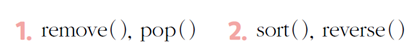

## 4) 2차원 리스트

- 2차원 리스트는 1차원 리스트를 여러개 연결한 것이다.
- 2개의 인덱스를 사용하는 리스트이다.
- 1차원 리스트는 확장한 것이 2차원 리스트라 정의할 수 있다.
- 2차원 리스트의 각 요소에 접근하기 위해서는 numList2[0][0]와 같이 2개의 인덱스를 사용해야된다.

예 ) 리스트이름[행][열]

[figure not shown]

#### 1차원 리스트

```python
numList1 = [10,20,30]

print('numList1: ', numList1)
```

```
numList1:  [10, 20, 30]
```

#### 2차원 리스트

- 가로로 연속해서 입력해도 되고, 가독성 좋게 나눠서 입력해도 된다.

```python
# numList2_Tr과 numList2는 같은 결과

numList2_Tr = [[10,20,30], [40,50,60], [70,80,90]]

numList2 = [[10,20,30],
            [40,50,60],
            [70,80,90]]


print('numList2_Tr: ', numList2_Tr)
print('numList2   : ', numList2)
```

```
numList2_Tr:  [[10, 20, 30], [40, 50, 60], [70, 80, 90]]
numList2   :  [[10, 20, 30], [40, 50, 60], [70, 80, 90]]
```

- 2차원 리스트의 첫번째 행

```python
print('numList2[0]:', numList2[0])
#print('numList2[1]: ', numList2[1])
#print('numList2[2]: ', numList2[2])
```

```
numList2[0]: [10, 20, 30]
```

- 2차원 리스트의 첫번째 행의 첫번째 열

```python
print('numList2[0][0]:', numList2[0][0])
#print('numList2[0][1]:', numList2[0][1])
#print('numList2[0][2]:', numList2[0][2])
```

```
numList2[0][0]: 10
```

### for문을 활용한 2차원 리스트 출력

- 인덱스가 두개이므로, 중첩 for문 사용

```python
numList2 = [[1, 2, 3, 4],
            [5, 6, 7, 8],
            [9, 0, 0, 0]]
```

- 2차원 리스트의 출력
- i번째 행과 k번째 열

```python
for i in range(0, 3) :
    for k in range(0, 4) :
        print(" ", numList2[i][k], end='')
    print("")
```

```
  1  2  3  4
  5  6  7  8
  9  0  0  0
```

### 심사위원 점수 결과 구하기

- 동계 올림픽에서 피겨 스케이팅 경기는, 심사위원 5명이 점수를 각 10점 만점으로 줄 수 있다.
- 홍길동 선수의 경기 후에 5명 심사위원의 점수를 리스트에 저장하고, 점수의 평균을 구하는 프로그램을 구현해보자.

[figure not shown]

```python
# 경기가 끝났음을 print()로 알리기
print("홍길동 선수 경기 끝났습니다.")


# 심사위원의 점수를 입력받을 리스트 score를 선언하고, 5번 반복하며 평가 점수를 입력받아 리스트에 추가하기
score = []
for i in range(5) :
    jumsu = int(input("평가 점수 ==>"))
    score.append(jumsu)


# 5명의 평가 점수를 더할 합계변수 hap을 선언하고 0으로 초기화하기 , hap에 리스트의 값을 모두 더하기
hap = 0
for i in range(5) :
    hap += score[i]


# 심사위원의 평균 점수를 구하여 출력하기
avg = hap / 5
print("심사위원 평균 점수 :", avg)
```

```
홍길동 선수 경기 끝났습니다.
평가 점수 ==>10
평가 점수 ==>5
평가 점수 ==>5
평가 점수 ==>5
평가 점수 ==>5
심사위원 평균 점수 : 6.0
```